# Holmes - Accumilibacter genome extraction

Mads Albertsen

June 28, 2016

## Introduction

This report documents the initial genome extraction of *Candidatus* Accumulibacter aalborgensis in [Albertsen et al., 2016: “Candidatus Propionivibrio aalborgensis”: a novel glycogen accumulating organism abundant in full-scale enhanced biological phosphorus removal plants](http://journal.frontiersin.org/article/10.3389/fmicb.2016.01033/abstract).

## Load the mmgenome package

In case you haven’t installed the [mmgenome package](http://madsalbertsen.github.io/mmgenome/), see the [Load data example](http://madsalbertsen.github.io/mmgenome/Load_data.html).

```r
library("mmgenome")
```

## Import data

The Rmarkdown file [Load_data.Rmd](http://madsalbertsen.github.io/mmgenome/Load_data_Holmes.html) describes the loading of the data and can be imported using the `mmimport` function. However, the preprocessed data can also be downloaded directly from figshare: [Holmes](https://dx.doi.org/10.6084/m9.figshare.3465371.v1). Hence, here we import the prepocessed data from figshare instead.

```r
load("Holmes.RData")
```

## Data overview

```r
colnames(d$scaffolds)
```

```
##  [1] "scaffold"   "length"     "gc"         "H09.06"     "H11.05"
##  [6] "H11.25"     "H12.13"     "H12.19"     "PC1"        "PC2"
## [11] "PC3"        "essential"  "rRNA16S"    "pps_phylum" "pps_class"
## [16] "pps_order"  "pps_family" "pps_genus"
```

The basic statistics of the full dataset can be summarised using the `mmstats` function.

```r
mmstats(d, ncov = 5)
```

```
##                 General Stats
## n.scaffolds          30725.00
## GC.mean                 48.20
## N50                   2951.00
## Length.total      50450465.00
## Length.max          230584.00
## Length.mean           1642.00
## Coverage.H09.06          0.31
## Coverage.H11.05          1.92
## Coverage.H11.25        253.90
## Coverage.H12.13         48.17
## Coverage.H12.19         28.32
## Ess.total              794.00
## Ess.unique             108.00
```

## Accumulibacter

The combination of the coverage of sample `H11.25` and `H11.05` provides the cleanest separation of the two genomes and are used for binning.

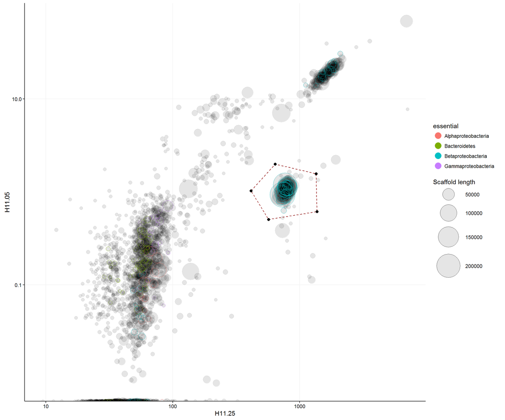

```r
p <- mmplot(data = d, x = "H11.25", y = "H11.05", log.x = T, log.y = T, color = "essential", minlength = 3000)

#p
#sel <- mmplot_locator(p)

sel <- data.frame(H11.25  =  c(413, 641, 1350, 1370, 569),
                  H11.05  =  c(1.03, 1.99, 1.57, 0.614, 0.506))

mmplot_selection(p, sel) +
  theme(axis.line.x = element_line(),
        axis.line.y = element_line())
```

The scaffolds included in the defined subspace are extracted using the `mmextract` function.

```r
dA <- mmextract(d, sel)
```

The `mmstats` function applies to any extracted object. Hence, it can be used directly on the subset.

```r
mmstats(dA, ncov = 5)
```

```
##                 General Stats
## n.scaffolds            143.00
## GC.mean                 62.20
## N50                  71862.00
## Length.total       4649134.00
## Length.max          230584.00
## Length.mean          32511.40
## Coverage.H09.06          0.38
## Coverage.H11.05          1.06
## Coverage.H11.25        777.72
## Coverage.H12.13        160.98
## Coverage.H12.19        156.38
## Ess.total              107.00
## Ess.unique             105.00
```

## Using paried-end connections

Until now we have just used coverage profiles to extract scaffolds related to our genome of interest. However, some scaffolds might be present in many copies (repeats) and hence have a much higher coverage than the rest of the genome. In addition, some scaffolds will by chance have a slightly different coverage profile than the rest of the genome and thereby also be missed.

The function `mmplot_network` can be used to generate a network plot of scaffolds connected by paired-end reads. We start by plotting the scaffolds we have in our current subset.

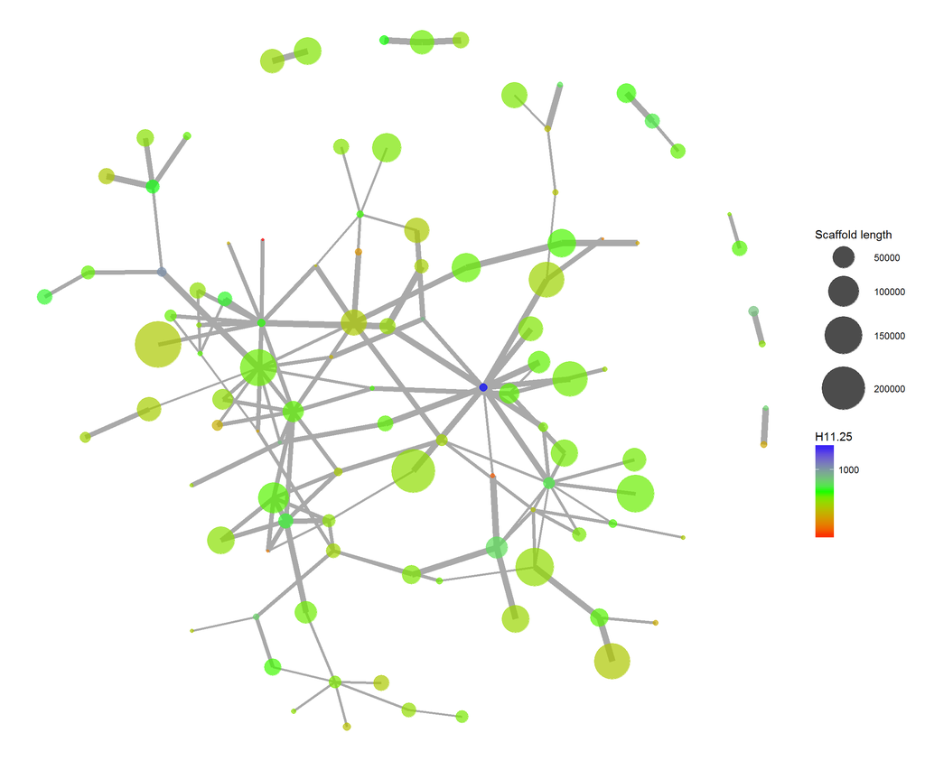

```r
mmplot_network(data = dA, network = pe, color = "H11.25", nconnections = 10, log.color = T)
```

```r
dB <- mmextract_network(subset = dA, original = d, network = pe, nconnections = 10, type = "direct")
```

## Subspace extraction 2

We finally remove the low abundant scaffolds that were included using the paired-end data.

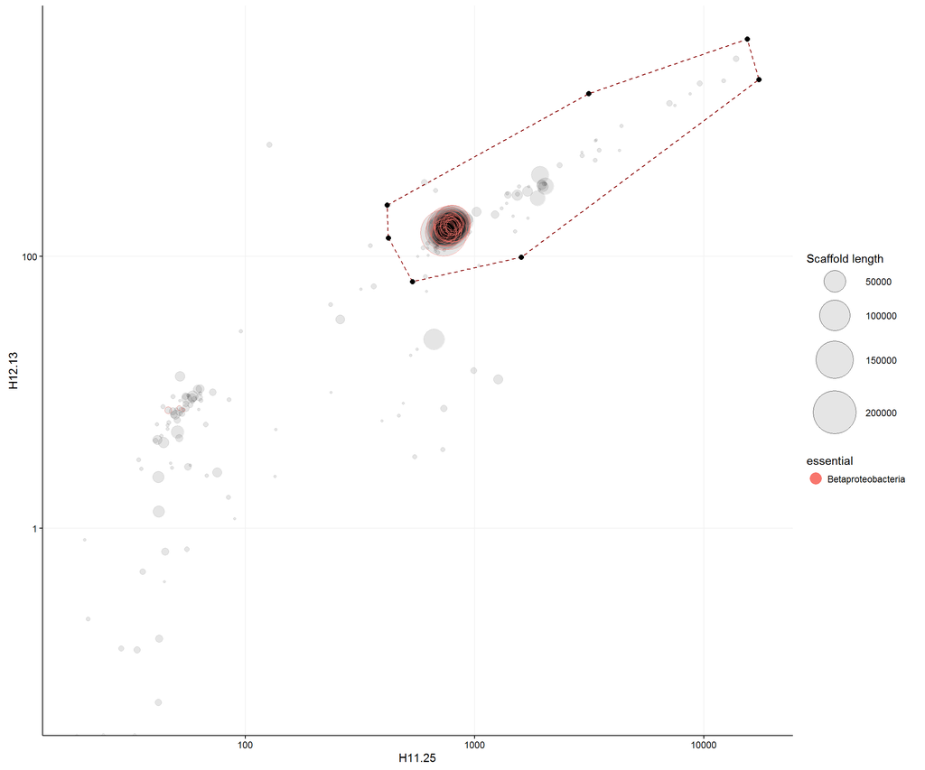

```r
p <- mmplot(data = dB, x = "H11.25", y = "H12.13", log.x = T, log.y = T, color = "essential")

#p
#sel <- mmplot_locator(p)

sel <- data.frame(H11.25  =  c(420, 535, 1600, 17400, 15500, 3150, 415),
                  H12.13  =  c(137, 65.1, 98.8, 2010, 4000, 1580, 240))

mmplot_selection(p, sel) +
  theme(axis.line.x = element_line(),
        axis.line.y = element_line())
```

Extract the scaffolds in the selection.

```r
dC <- mmextract(dB, sel)
```

Look at the basic stats.

```r
mmstats(dC, ncov = 5)
```

```
##                 General Stats
## n.scaffolds            189.00
## GC.mean                 62.20
## N50                  70641.00
## Length.total       4798751.00
## Length.max          230584.00
## Length.mean          25390.20
## Coverage.H09.06          0.41
## Coverage.H11.05          1.46
## Coverage.H11.25        839.39
## Coverage.H12.13        172.67
## Coverage.H12.19        164.06
## Ess.total              107.00
## Ess.unique             105.00
```

## Export the scaffolds

Now that we are happy with the genome bin, the scaffolds can be exported to a separate fasta file using `mmexport`.

```r
mmexport(data=dC, assembly=assembly, file = "Accumulibacter.fa")
```